# PalEON Summer Course: MCMC with JAGS module

## August 2016

## Chris Paciorek

In this module, we'll do some hands-on work to fit a time series model via MCMC with JAGS.

Recall our mixed model (rat pups) and HMM. Let's work through fitting such models using JAGS (this could also be done in BUGS).

Here we'll use simulated data.

```r
theta <- 2
sigma <- 2
nMoms <- 10

## IGNORE THE MAN BEHIND THE CURTAIN ####
set.seed(0)
mus <- rgamma(nMoms, shape = 2, scale = 1)
nPups <- rbinom(nMoms, 15, prob = .4)
momIds <- rep(1:nMoms, times = nPups)
y <- rnorm(sum(nPups), mus[momIds], sigma)
n <- sum(nPups)
## IGNORE THE CODE ABOVE
```

Here's the JAGS code for the model. Note that the normal distribution in JAGS is in terms of the precision (one over the variance), so our code uses `dnorm()` differently than we do in R (which is in terms of the standard deviation).

```r
### model function (note this looks like R code but is really JAGS code for defining a model
mixedModel <- function(){
  # (hyper)priors
  sigma ~ dunif(0, 100)
  tau ~ dunif(0, 100)
  theta ~ dnorm(0,.00001)
  # some transformations to get precisions from sd's
  tau2Inv <- 1/(tau^2)
  sigma2Inv <- 1/(sigma^2)
  # latent value layer
  for(i in 1:nMoms){
    mus[i] ~ dnorm(theta, tau2Inv)
  }
  # likelihood
  for(j in 1:n)
    {
      y[j] ~ dnorm(mus[momIds[j]], sigma2Inv)
    }
}
```

Here's how we run it from R.

```r
library(R2jags, quietly = TRUE)
out <- jags(data = list(y = y, n = n, nMoms = nMoms, momIds = momIds),
  parameters.to.save = c('theta','sigma','tau', 'mus'), n.chains = 1,
  n.iter = 2000, n.burnin = 1000, model.file = mixedModel, DIC = FALSE)
```

```
## module glm loaded
```

```
## module dic loaded
```

Let's look at some figures that illustrate these checks. (I'm not putting these plots in the HTML, but we'll see them in R.)

```r
out.mcmc <- as.mcmc(out)[[1]]
plot(out.mcmc)
crosscorr.plot(out.mcmc)
mu1 <- c(out.mcmc[ , 1])
sigma <- c(out.mcmc[ , 11])
tau <- c(out.mcmc[ , 12])
theta <- c(out.mcmc[ , 13])
plot(mu1, theta)
plot(sigma, tau)
```

For the sake of time, I'll leave out the use of multiple chains and effective sample sizes, but these are very good ideas in general.

# HMM for pollen

In the forward model module, we worked on a HMM with a binomial model for the data (the likelihood) and a random walk Markov model on the logit scale as our model for the latent process. Now we're going to make that model a bit more sophisticated, building on the HMM we saw in the Bayes module.

\[ y_{t} \sim \mbox{Binom}(n_{t},\theta_{t}). \] \[ \mbox{logit}(\theta_t) \sim N(\mu + \rho (\mbox{logit}(\theta_{t-1}) - \mu), \tau^2) \]

\(\mu\) allows the model to have an arbitrary overall mean, while \(\rho\) controls the auto-correlation over time. When \(\rho = 1\), we have a random walk model, and when \(\rho \in (-1, 1)\) we have an autoregressive model.

Now let's fit the model to fake data simulated from the model (in this case we know the statistical model is a good model for the data).

First I'll generate fake data (i.e., simulating from the forward model, as we did yesterday).

```r
nT <- 100
n <- 50
theta0 <- 0.2
tau <- 0.2

logit <- function(x) log(x/(1-x))
expit <- function(x) exp(x) / (1+exp(x))

simHMM <- function(nT, n, mu = 0, rho = 1, tau, theta0) {
  if(length(n) == 1) n <- rep(n, nT)
  theta <- logitTheta <- y <- rep(0, nT)
  for(i in seq_len(nT)) {
    if(i == 1) {
      logitTheta[i] <- rnorm(1, mu + rho*(logit(theta0) - mu), tau)
    } else {
      logitTheta[i] <- rnorm(1, mu + rho*(logitTheta[i-1] - mu), tau)
    }
    y[i] <- rbinom(1, n[i], expit(logitTheta[i]))
  }
  return(data.frame(n = n, y = y, theta = expit(logitTheta)))
}

set.seed(0)
out <- simHMM(n = n, nT = nT, rho = .95, mu = -1, tau = tau, theta0 = theta0)
n <- out$n
y <- out$y
theta <- out$theta
```

Here's the BUGS code for the model.

```r
hmmFake <- function(){
    # (hyper)priors
        mu ~ dunif(-5, 5)
        rho ~ dunif(-1, 1)
    tau ~ dunif(0, 100)
    logitTheta0 ~ dnorm(0, .000001)
    # deterministic transformation
    tau2Inv <- 1/(tau^2)

    # latent process evolution and likelihood
    logitTheta[1] ~ dnorm(mu + rho*(logitTheta0 - mu), tau2Inv)
        theta[1] <- exp(logitTheta[1])/(1+exp(logitTheta[1]))
        y[1] ~ dbin(theta[1], n[1])
    for(i in 2:nT){
        logitTheta[i] ~ dnorm(mu + rho*(logitTheta[i-1] - mu), tau2Inv)
        theta[i] <- exp(logitTheta[i])/(1+exp(logitTheta[i]))
        y[i] ~ dbin(theta[i], n[i])
    }
}
```

Now fit the model using JAGS and look at the fits.

```r
out <- jags(data = list(nT = nT, n = n, y = y),
    parameters.to.save = c('theta', 'mu', 'rho', 'tau'),
    n.chains = 1, n.iter = 10000, n.burnin = 2000,
    model.file = hmmFake, DIC = FALSE)
```

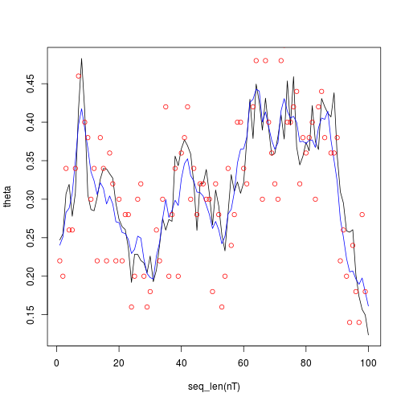

```r
out.mcmc <- as.mcmc(out)[[1]]
colNames <- dimnames(out.mcmc)[[2]]
whichTheta <- grep('theta', colNames)
thetaPost <- out.mcmc[ , whichTheta]
thetaNames <- dimnames(thetaPost)[[2]]
index <- gsub("theta\\[", "", thetaNames)
index <- as.numeric(gsub("\\]", "", index))
thetaPost <- thetaPost[ , order(index)]

plot(seq_len(nT), theta, type = 'l')
lines(seq_len(nT), colMeans(thetaPost), col = 'blue')
points(seq_len(nT), y/n, col = 'red')
```

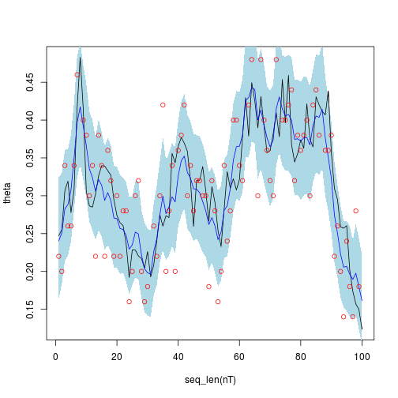

```r
plot(seq_len(nT), theta, type = 'l')
quants <- apply(thetaPost, 2, quantile, c(.025, .975))
# lines(seq_len(nT), quants[1, ], col = 'blue', lty = 2)
# lines(seq_len(nT), quants[2, ], col = 'blue', lty = 2)
polygon(cbind(c(seq_len(nT), nT:1, 1), c(quants[1, ], rev(quants[2, ]), quants[1, 1])), border = NA, col = 'lightblue')
lines(seq_len(nT), theta)
lines(seq_len(nT), colMeans(thetaPost), col = 'blue')
points(seq_len(nT), y/n, col = 'red')
```

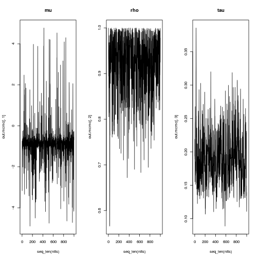

```r
par(mfrow = c(1, 3))
nIts <- nrow(out.mcmc)
plot(seq_len(nIts), out.mcmc[ , 1], type = 'l', main = 'mu')
plot(seq_len(nIts), out.mcmc[ , 2], type = 'l', main = 'rho')
plot(seq_len(nIts), out.mcmc[ , 3], type = 'l', main = 'tau')
```

```r
print(mean(out.mcmc[201:1000, 1]))
```

```
## [1] -0.8556151
```

```r
print(mean(out.mcmc[201:1000, 2]))
```

```
## [1] 0.9191683
```

```r
print(mean(out.mcmc[201:1000, 3]))
```

```
## [1] 0.190394
```

Questions:

- Have we done better than the empirical estimates? Why?
- Any ideas why we might not be able to estimate \(\mu\) very well?

Note: in this model, both \(\rho\) and \(\tau^{2}\) determine how quickly the process changes over time. Smaller values of \(\rho\) and larger values of \(\tau\) allow more jumpiness while the reverse force smoother change.

Let's also see how we can choose or generate our own starting values. (See the help on `jags()` for how to set specific initial values.) I didn't include the output in the HTML, but we can see it in R.

```r
# with a function
inits <- function(){
    list('mu' = runif(1, -3, 3), 'rho' = runif(1, 0.5, 1), 'tau' = runif(1, .01, 5), 'logitTheta' = rnorm(nT, 0, 3))
}
# see the documentation for jags()
out <- jags(data = list(nT = nT, n = n, y = y), inits = inits, parameters.to.save = c('mu', 'tau', 'rho'),
    n.thin = 1, n.chains = 3, n.iter = 1000, n.burnin = 0, model.file = hmmFake, DIC = FALSE)
traceplot(out, mfrow = c(1, 3), ask = FALSE)
```

Finally let's do an initial fit to real data from Glimmerglass Lake, which we've already worked with some. First we'll read in the data.

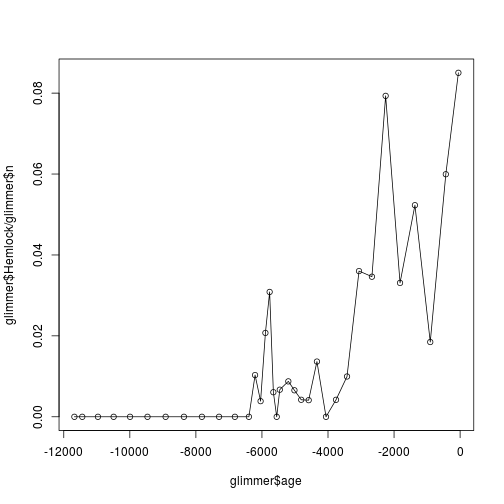

```r
data <- read.csv('data/upperMidwest/pollenTimeSeries.csv')
glimmer <- data[data$site.name == "Glimmerglass Lake", ]
glimmer$age <- -glimmer$age
glimmer <- glimmer[order(glimmer$age), ]
glimmer$n <- rowSums(glimmer[ , 13:ncol(glimmer)])
nT <- nrow(glimmer)
plot(glimmer$age, glimmer$Hemlock/glimmer$n)
lines(glimmer$age, glimmer$Hemlock/glimmer$n)
```

```r
y <- glimmer$Hemlock
n <- round(glimmer$n)
```

Here's the BUGS code for the model.

```r
hmm <- function(){
  mu ~ dunif(-5, 5)
  rho ~ dunif(-1, 1)
  tau ~ dunif(0, 100)
    logitTheta0 ~ dnorm(0, .000001)
  tau2Inv <- 1/(tau^2)

    # latent process evolution and likelihood
    logitTheta[1] ~ dnorm(mu + rho*(logitTheta0 - mu), tau2Inv)
  theta[1] <- exp(logitTheta[1])/(1+exp(logitTheta[1]))
  y[1] ~ dbin(theta[1], n[1])
    for(i in 2:nT){
        logitTheta[i] ~ dnorm(mu + rho*(logitTheta[i-1] - mu), tau2Inv)
        theta[i] <- exp(logitTheta[i])/(1+exp(logitTheta[i]))
        y[i] ~ dbin(theta[i], n[i])
    }
}
```

And let's fit the model.

```r
out <- jags(data = list(nT = nT, n = n, y = y), parameters.to.save = c('rho', 'tau', 'theta'),
    n.chains = 1, n.iter = 10000, n.burnin = 2000, model.file = hmm, DIC = FALSE)
```

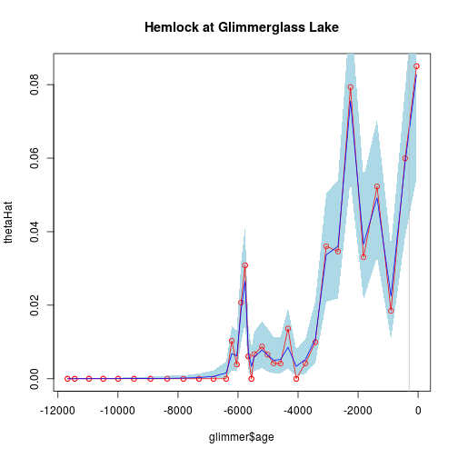

```r
out.mcmc <- as.mcmc(out)[[1]]
thetaHat <- glimmer$Hemlock/glimmer$n

colNames <- dimnames(out.mcmc)[[2]]
whichTheta <- grep('theta', colNames)
thetaPost <- out.mcmc[201:1000 , whichTheta]
thetaNames <- dimnames(thetaPost)[[2]]
index <- gsub("theta\\[", "", thetaNames)
index <- as.numeric(gsub("\\]", "", index))
thetaPost <- thetaPost[ , order(index)]

par(mfrow = c(1,1))
plot(glimmer$age, thetaHat, col = 'red')
quants <- apply(thetaPost, 2, quantile, c(.025, .975))
polygon(cbind(c(glimmer$age, rev(glimmer$age), glimmer$age[1]), c(quants[1, ],
    rev(quants[2, ]), quants[1, 1])), border = NA, col = 'lightblue')
lines(glimmer$age, thetaHat, col = 'red')
points(glimmer$age, thetaHat, col = 'red')
lines(glimmer$age, colMeans(thetaPost), col = 'blue')
title('Hemlock at Glimmerglass Lake')
abline(v = 1650 - 1950, col = 'grey')
```

We'll check the mixing in R and see that this chain has not run for nearly long enough.

# Next steps

- Discussion questions
  - How we would code up a model that treats depth or radiocarbon years as the time index and correctly accounts for the irregular spacing of data.
  - Let's consider some of the aspects of the data and the scientific context that have been left out of our model for pollen.
- Practice problems
  - Change the prior on \(\tau\) (currently uniform, as recommended in Gelman (2006; Bayesian Analysis 1:515)) to be an gamma prior on \(\tau^2\) with parameters 0.001 and 0.001. Assess whether the inference changes for either \(\tau\) or the species composition.
  - (Advanced) Rework the JAGS code for Glimmerglass Lake to use radiocarbon years as the time index.